# 29 Curve sketching

[output not shown]

This section uses the following add-on packages:

```julia
using CalculusWithJulia
using Plots
plotly()
using SymPy
using Roots
import Polynomials: variable, Polynomial, RationalFunction # avoid name clash
```

[output not shown]

Drawing a sketch of a function can be enhanced by identifying as many of the following as possible before filling in a curve representing the function:

- asymptotic behaviour (as $x \rightarrow \pm \infty$),
- periodic behaviour,
- vertical asymptotes,
- the $y$ intercept,
- any $x$ intercept(s),
- local peaks and valleys (relative extrema).
- concavity

Figure 29.1 and Figure 29.2 illustrate this approach for two different types of functions.

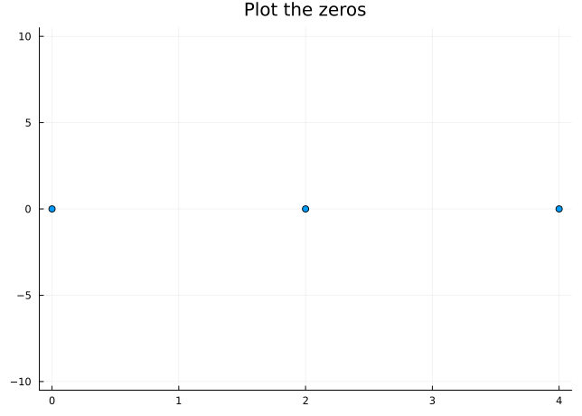

Figure 29.1: After identifying asymptotic behaviors, a curve sketch involves identifying the $y$ intercept, if applicable; the $x$ intercepts, if possible; the local extrema; and changes in concavity. From there a sketch fills in between the points. In this example, the periodic function $f(x) = 10\cdot\sin(\pi/2\cdot x)$ is sketched over $[0,4]$.

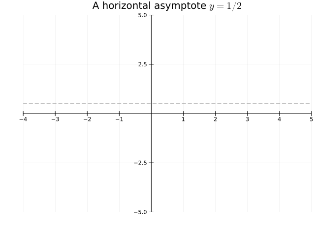

Figure 29.2: After identifying asymptotic behaviors, a curve sketch involves identifying the $y$ intercept, if applicable; the $x$ intercepts, if possible; the local extrema; and changes in concavity. From there a sketch fills in between the points. In this example, the rational function $f(x) = 1/2 + (x-1)^2/((x-2)^2 \cdot (x+1))$ is sketched.

Though this approach is most useful for hand-sketches, the underlying concepts are important for properly framing graphs made with the computer.

We can easily make a graph of a function over a specified interval. What is not always so easy is to pick an interval that shows off the features of interest. In the section on rational functions there was a discussion about how to draw graphs for rational functions so that horizontal and vertical asymptotes can be seen. These are properties of the “large.” In this section, we build on this, but concentrate now on more local properties of a function.

##### Example

Produce a graph of the function $f(x) = x^4 -13x^3 + 56x^2-92x + 48$.

We identify this as a fourth-degree polynomial with positive leading coefficient. Hence it will eventually look $U$-shaped. If we graph over a too-wide interval, that is all we will see. Rather, we do some work to produce a graph that shows the zeros, peaks, and valleys of $f(x)$. To do so, we need to know the extent of the zeros. We can try some theory, but instead we just guess and if that fails, will work harder:

```julia
f(x) = x^4 - 13x^3 + 56x^2 -92x + 48
rts = find_zeros(f, -10, 10)
```

```
4-element Vector{Float64}:
 0.9999999999999999
 2.000000000000005
 4.000000000000004
 6.000000000000003
```

As we found $4$ roots, we know by the fundamental theorem of algebra we have them all. This means, our graph need not focus on values much larger than $6$ or much smaller than $1$.

To know where the peaks and valleys are, we look for the critical points:

```julia
cps = find_zeros(f', 1, 6)
```

```
3-element Vector{Float64}:
 1.4257862014364733
 3.0704645527012464
 5.253749245862282
```

Because we have the $4$ distinct zeros, we must have the peaks and valleys appear in an interleaving manner, so a search over $[1,6]$ finds all three critical points and without checking, they must correspond to relative extrema.

Next we identify the *inflection points* which are among the zeros of the second derivative (when defined):

```julia
ips = find_zeros(f'', 1, 6)
```

```
2-element Vector{Float64}:
 2.1413221086958276
 4.358677891304171
```

If there is no sign change for either $f'$ or $f''$ over $[a,b]$ then the sketch of $f$ on this interval must be one of:

- increasing and concave up (if $f' > 0$ and $f'' > 0$)
- increasing and concave down (if $f' > 0$ and $f'' < 0$)
- decreasing and concave up (if $f' < 0$ and $f'' > 0$)
- decreasing and concave down (if $f' < 0$ and $f'' < 0$)

This aids in sketching the graph between the critical points and inflection points.

We finally check that if we were to just use $[0,7]$ as a domain to plot over that the function doesn’t get too large to mask the oscillations. This could happen if the $y$ values at the end points are too much larger than the $y$ values at the peaks and valleys, as only so many pixels can be used within a graph. For this we have:

```julia
f.([0, cps..., 7])
```

```
5-element Vector{Float64}:
  48.0
  -2.8788980209096167
   6.035382559783841
 -12.949453288874281
  90.0
```

The values at $0$ and at $7$ are a bit large, as compared to the relative extrema, and since we know the graph is eventually $U$-shaped, this offers no insight. So we narrow the range a bit for the graph of Figure 29.3.

```julia
plot(f, 0.5, 6.5)
```

Figure 29.3: Plot of $f(x) = x^4 - 13x^3 + 56x^2 -92x + 48$ over $[0.5, 6.5]$

This sort of analysis can be automated. The plot “recipe” for polynomials from the `Polynomials` package does similar considerations to choose a viewing window:

```julia
𝐱 = variable(Polynomial)
plot(f(𝐱))   # f(𝐱) of Polynomial type
```

Figure 29.4: Plot of polynomial `f(x)` produced by a plot recipe

##### Example

Graph the rational function

$$f(x) = \frac{(x-1)\cdot(x-3)^2}{x \cdot (x-2)}.$$

Not much to do here if you are satisfied with a graph that only gives insight into the asymptotes of this rational function (Figure 29.5).

```julia
f(x) = ( (x-1)*(x-3)^2 ) / (x * (x-2) )
plot(f, -50, 50)
```

Figure 29.5: Plot of rational function over $[-50, 50] shows some features, but not all that are commonly of interest

We can see the slant asymptote and hints of vertical asymptotes, but, we’d like to see more of the basic features of the graph.

Previously, we have discussed rational functions and their asymptotes. This function has numerator of degree $3$ and denominator of degree $2$, so will have a slant asymptote. As well, the zeros of the denominator, $0$ and $2$, will lead to vertical asymptotes.

To identify how wide a viewing window should be, for the rational function the asymptotic behaviour is determined after the concavity is done changing and we are past all relative extrema, so we should take an interval that includes all potential inflection points and critical points:

```julia
cps = find_zeros(f', -10, 10)
poss_ips = find_zeros(f'', (-10, 10))
extrema(union(cps, poss_ips))
```

```
(-2.1527576020103956, 3.0)
```

So a range over $[-5,5]$ should display the key features including the slant asymptote.

Previously we used the `rangeclamp` function defined in `CalculusWithJulia` to avoid the distortion that vertical asymptotes can have:

Figure 29.6: Plot of rational function over identified domain $[-5, 5]$ and passing through `rangeclamp` to avoid spurious lines

With the graph in Figure 29.6, we can now clearly see in the graph the two zeros at $x=1$ and $x=3$, the vertical asymptotes at $x=0$ and $x=2$, and the slant asymptote.

Again, this sort of analysis can be systematized. The rational function type in the `Polynomials` package takes a stab at that, but isn’t quite so good at capturing the slant asymptote:

```julia
x = variable(RationalFunction)
plot(f(x))  # f(x) of RationalFunction type
```

Figure 29.7: Plot of rational function using a plot recipe

##### Example

Consider the function $V(t) = 170 \sin(2\pi\cdot 60 \cdot t)$, a model for the alternating current waveform for an outlet in the United States. Create a graph.

Blindly trying to graph this (Figure 29.8), we will see immediate issues.

```julia
V(t) = 170 * sin(2*pi*60*t)
plot(V, -2pi, 2pi)
```

Figure 29.8: Plot of current function, $V(t)$ showing it is highly oscillatory

Ahh, this periodic function is *too* rapidly oscillating to be plotted without care. We recognize this as being of the form $V(t) = a\cdot\sin(c\cdot t)$, so where the sine function has a period of $2\pi$, this will have a period of $2\pi/c$, or $1/60$. So instead of using $(-2\pi, 2\pi)$ as the interval to plot over, we need something much smaller:

```julia
plot(V, -1/60, 1/60)
```

Figure 29.9: Plot of two periods of highly oscillatory function, $V(t)$

##### Example

Plot the function $f(x) = \ln(x/100)/x$.

We guess that this function has a *vertical* asymptote at $x=0+$ and a horizontal asymptote as $x \rightarrow \infty$, we verify through:

```julia
@syms x
ex = log(x/100)/x
limit(ex, x=>0, dir="+"), limit(ex, x=>oo)
```

```
(-oo, 0)
```

The $\ln(x/100)$ part of $f$ goes $-\infty$ as $x \rightarrow 0+$; yet $f(x)$ is eventually positive as $x \rightarrow \infty$. So a graph should

- not show too much of the vertical asymptote
- capture the point where $f(x)$ must cross $0$
- capture the point where $f(x)$ has a relative maximum
- show enough past this maximum to indicate to the reader the eventual horizontal asymptote.

For that, we need to get the $x$ intercepts and the critical points. The $x/100$ means this graph has some scaling to it, so we first look between $0$ and $200$:

```julia
find_zeros(ex, 0, 200)  # domain is (0, oo)
```

```
1-element Vector{Float64}:
 100.0
```

Trying the same for the critical points comes up empty. We know there is one, but it is past $200$. Scanning wider, we see:

```julia
find_zeros(diff(ex,x), 0, 500)
```

```
1-element Vector{Float64}:
 271.8281828459045
```

But it isn’t! The function takes its time getting back towards $0$. We know that there must be a change of concavity as $x \rightarrow \infty$, as there is a horizontal asymptote. We look for the anticipated inflection point to ensure our graph includes that:

```julia
find_zeros(diff(ex, x, x), 1, 5000)
```

```
1-element Vector{Float64}:
 448.1689070338064
```

Figure 29.11: Plot of $f(x) = \ln(x/100)/x$ over $[75, 1500]$

## 29.1 Questions

###### Question

Consider the graph of a rational function in Figure 29.12.

Figure 29.12: Graph of rational function

What kind of *asymptotes* does it appear to have?

Vertical asymptotes at \(x=-1\) and \(x=1\) and a horizontal asymptote \(y=1\)

Just a horizontal asymptote, \(y=0\)

Just vertical asymptotes at \(x=-1\) and \(x=1\)

Vertical asymptotes at \(x=-1\) and \(x=1\) and a slant asymptote

###### Question

Consider the function $p(x) = x + 2x^2 + 3x^3 + 4x^4 + 5x^5 +6x^6$. Which interval shows more than a $U$-shaped graph that dominates for large $x$ due to the leading term being $6x^6$?

(Find an interval that contains the zeros, critical points, and inflection points.)

\((-5,5)\), the default bounds of a calculator

\((-3.5, 3.5)\), the bounds given by Cauchy for the real roots of \(p\)

\((-1, 1)\), as many special polynomials have their roots in this interval

\((-1.1, .25)\), as this contains all the roots, the critical points, and inflection points and just a bit more

###### Question

Let $f(x) = x^3/(9-x^2)$.

What points are *not* in the domain of $f$?

The values of `find_zeros(f, -10, 10)`: `[-3, 0, 3]`

The values of `find_zeros(f', -10, 10)`: `[-5.19615, 0, 5.19615]`

The values of `find_zeros(f'', -10, 10)`: `[-3, 0, 3]`

The zeros of the numerator: `[0]`

The zeros of the denominator: `[-3, 3]`

The value of `f(0)`: `0`

None of these choices

The $x$-intercepts are:

The values of `find_zeros(f, -10, 10)`: `[-3, 0, 3]`

The values of `find_zeros(f', -10, 10)`: `[-5.19615, 0, 5.19615]`

The values of `find_zeros(f'', -10, 10)`: `[-3, 0, 3]`

The zeros of the numerator: `[0]`

The zeros of the denominator: `[-3, 3]`

The value of `f(0)`: `0`

None of these choices

The $y$-intercept is:

The values of `find_zeros(f, -10, 10)`: `[-3, 0, 3]`

The values of `find_zeros(f', -10, 10)`: `[-5.19615, 0, 5.19615]`

The values of `find_zeros(f'', -10, 10)`: `[-3, 0, 3]`

The zeros of the numerator: `[0]`

The zeros of the denominator: `[-3, 3]`

The value of `f(0)`: `0`

None of these choices

There are *vertical asymptotes* at $x=\dots$?

The values of `find_zeros(f', -10, 10)`: `[-5.19615, 0, 5.19615]`

The values of `find_zeros(f, -10, 10)`: `[-3, 0, 3]`

None of these choices

The values of `find_zeros(f'', -10, 10)`: `[-3, 0, 3]`

The zeros of the denominator: `[-3, 3]`

The value of `f(0)`: `0`

The zeros of the numerator: `[0]`

The *slant* asymptote has slope?

The function has critical points at

The values of `find_zeros(f, -10, 10)`: `[-3, 0, 3]`

The values of `find_zeros(f', -10, 10)`: `[-5.19615, 0, 5.19615]`

The values of `find_zeros(f'', -10, 10)`: `[-3, 0, 3]`

The zeros of the numerator: `[0]`

The zeros of the denominator: `[-3, 3]`

The value of `f(0)`: `0`

None of these choices

The function has relative extrema at

The values of `find_zeros(f, -10, 10)`: `[-3, 0, 3]`

The values of `find_zeros(f', -10, 10)`: `[-5.19615, 0, 5.19615]`

The values of `find_zeros(f'', -10, 10)`: `[-3, 0, 3]`

The zeros of the numerator: `[0]`

The zeros of the denominator: `[-3, 3]`

The value of `f(0)`: `0`

None of these choices

The function has inflection points at

The values of `find_zeros(f, -10, 10)`: `[-3, 0, 3]`

The values of `find_zeros(f', -10, 10)`: `[-5.19615, 0, 5.19615]`

The values of `find_zeros(f'', -10, 10)`: `[-3, 0, 3]`

The zeros of the numerator: `[0]`

The zeros of the denominator: `[-3, 3]`

The value of `f(0)`: `0`

None of these choices

###### Question

A function $f$ has

- zeros of $\{-0.7548\dots, 2.0\}$,
- critical points at $\{-0.17539\dots, 1.0, 1.42539\dots\}$,
- inflection points at $\{0.2712\dots,1.2287\}$.

Does Figure 29.13 show a possible graph of $f$?

Figure 29.13: Plot of $f(x)$ over $[-1, 1.25]$

Yes

No

###### Question

Two models for population growth are *exponential* growth: $P(t) = P_0 a^t$ and [logistic growth](https://en.wikipedia.org/wiki/Logistic_function#In_ecology:_modeling_population_growth): $P(t) = K P_0 a^t / (K + P_0(a^t - 1))$. The exponential growth model has growth rate proportional to the current population. The logistic model has growth rate depending on the current population *and* the available resources (which can limit growth).

Letting $K=50$, $P_0=5$, and $a= e^{1/4}$, the plots in Figure 29.14 $ shows somewhat similar behaviour over $[0,5].

```julia
K, P0, a = 50, 5, exp(1/4)
exponential_growth(t) = P0 * a^t
logistic_growth(t) = K * P0 * a^t / (K + P0*(a^t-1))

plot(exponential_growth, 0, 5; label="exponential growth")
plot!(logistic_growth; label="logistic growth")
```

Figure 29.14: Plot of exponential growth model and logisitc growth model over $[0,5]$

Does a plot over $[0,50]$ show qualitatively similar behaviour?

Yes

No

Exponential growth has $P''(t) = P_0 a^t \log(a)^2 > 0$, so has no inflection point. By plotting over a sufficiently wide interval, can you answer: does the logistic growth model have an inflection point?

Yes

No

If yes, find it numerically:

The available resources are quantified by $K$. As $K \rightarrow \infty$ what is the limit of the logistic growth model:

The limit does not exist

The exponential growth model

The limit is \(P_0\)

###### Question

Why are sub-intervals where the second derivative is large different than those where the second derivative is small?

The function will be much larger (in absolute value) when the second derivative is large, so there needs to be more points to capture the shape

The function will have more curvature when the second derivative is large, so there needs to be more points to capture the shape

The function will increase (or decrease) rapidly when the second derivative is large, so there needs to be more points to capture the shape

###### Question

Is there a nice algorithm to identify what domain a function should be plotted over to produce an informative graph? [Wilkinson](https://www.cs.uic.edu/~wilkinson/Publications/plotfunc.pdf) has some suggestions. (Wilkinson is well known to the `R` community as the specifier of the grammar of graphics.) It is mentioned that “finding an informative domain for a given function depends on at least three features: periodicity, asymptotics, and monotonicity.”

Why would periodicity matter?

An informative graph needs to show several periods, as that will allow proper computation for the \(y\) axis range.

An informative graph only needs to show one or two periods, as others can be inferred.

An informative graph need only show a part of the period, as the rest can be inferred.

Why should asymptotics matter?

A horizontal asymptote must be plotted from \(-\infty\) to \(\infty\)

A slant asymptote must be plotted over a very wide domain so that it can be identified.

A vertical asymptote can distort the \(y\) range, so it is important to avoid too-large values

Monotonicity means increasing or decreasing. This is important for what reason?

For monotonic regions, a large slope or very concave function might require more care to plot

For monotonic regions, the function will have a vertical asymptote, so the region should not be plotted

For monotonic regions, a function is basically a straight line